# Import the necessary packages

# Univariate Results:

## 1. No missing values found.

## 2. There are few people with negative balance

## 3. Most of the categorical variable has disproportinate 'yes' compared to 'no' for term deposit subscription.

## 4. There is some imbalance in variables like target with 'no' is way higher than the 'yes'.

## 5. Age has lot of outliers and does not give any insight on the term deposit.

# Deliverable - 1

## Heat map to visualize the correlation between variables

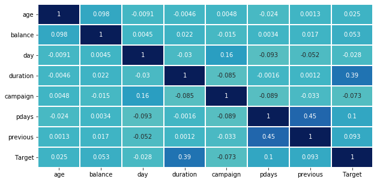

```python
bankDf['Target'].replace(['no','yes'],[0,1],inplace=True)
plot.figure(figsize=(10,5))
sns.heatmap(bankDf.corr(),annot=True,linewidth=1,center=0,cbar=False,cmap='YlGnBu')
plot.show()
```

## Pairplot to draw the plot between different variables

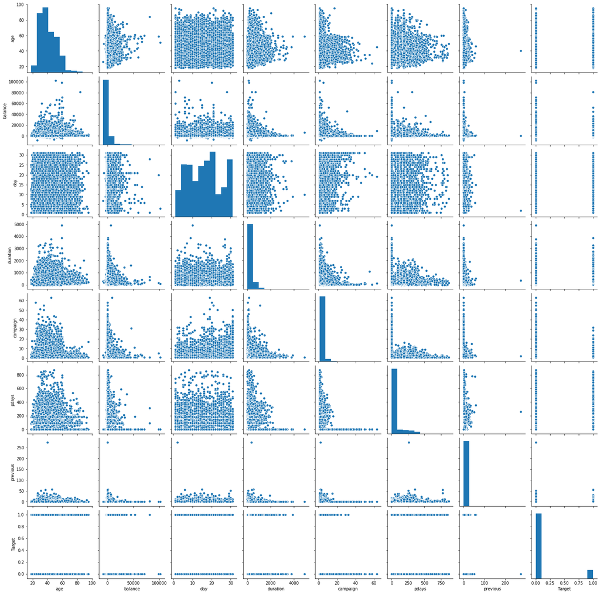

```python
sns.pairplot(bankDf)
plot.show()
```

## Most of the data are non linear and assymetric

## Correlation factor does not help to select the feature as it has weak relationship among the variables

## Only duration has signifcant impact on the Target and all other predictor variables have less impact. We can start dropping them and check the scores as its not impacting the target.

# Deliverable - 2

## Data preparation

```python
copyBankDf = bankDf.copy()
copyBankDf = pd.get_dummies(copyBankDf,columns=['education','month','job','default','loan','housing','marital','contact','poutcome'])
```

```python
copyBankDf
```

|  | age | balance | day | duration | campaign | pdays | previous | Target | education_primary | education_secondary | ... | marital_divorced | marital_married | marital_single | contact_cellular | contact_telephone | contact_unknown | poutcome_failure | poutcome_other | poutcome_success | poutcome_unknown |
| --- | --- | --- | --- | --- | --- | --- | --- | --- | --- | --- | --- | --- | --- | --- | --- | --- | --- | --- | --- | --- | --- |
| 0 | 58 | 2143 | 5 | 261 | 1 | -1 | 0 | 0 | 0 | 0 | ... | 0 | 1 | 0 | 0 | 0 | 1 | 0 | 0 | 0 | 1 |
| 1 | 44 | 29 | 5 | 151 | 1 | -1 | 0 | 0 | 0 | 1 | ... | 0 | 0 | 1 | 0 | 0 | 1 | 0 | 0 | 0 | 1 |
| 2 | 33 | 2 | 5 | 76 | 1 | -1 | 0 | 0 | 0 | 1 | ... | 0 | 1 | 0 | 0 | 0 | 1 | 0 | 0 | 0 | 1 |
| 3 | 47 | 1506 | 5 | 92 | 1 | -1 | 0 | 0 | 0 | 0 | ... | 0 | 1 | 0 | 0 | 0 | 1 | 0 | 0 | 0 | 1 |
| 4 | 33 | 1 | 5 | 198 | 1 | -1 | 0 | 0 | 0 | 0 | ... | 0 | 0 | 1 | 0 | 0 | 1 | 0 | 0 | 0 | 1 |
| ... | ... | ... | ... | ... | ... | ... | ... | ... | ... | ... | ... | ... | ... | ... | ... | ... | ... | ... | ... | ... | ... |
| 45206 | 51 | 825 | 17 | 977 | 3 | -1 | 0 | 1 | 0 | 0 | ... | 0 | 1 | 0 | 1 | 0 | 0 | 0 | 0 | 0 | 1 |
| 45207 | 71 | 1729 | 17 | 456 | 2 | -1 | 0 | 1 | 1 | 0 | ... | 1 | 0 | 0 | 1 | 0 | 0 | 0 | 0 | 0 | 1 |
| 45208 | 72 | 5715 | 17 | 1127 | 5 | 184 | 3 | 1 | 0 | 1 | ... | 0 | 1 | 0 | 1 | 0 | 0 | 0 | 0 | 1 | 0 |
| 45209 | 57 | 668 | 17 | 508 | 4 | -1 | 0 | 0 | 0 | 1 | ... | 0 | 1 | 0 | 0 | 1 | 0 | 0 | 0 | 0 | 1 |
| 45210 | 37 | 2971 | 17 | 361 | 2 | 188 | 11 | 0 | 0 | 1 | ... | 0 | 1 | 0 | 1 | 0 | 0 | 0 | 1 | 0 | 0 |

45211 rows × 52 columns

```python
copyBankDf.dtypes
```

```
age                    int64
balance                int64
day                    int64
duration               int64
campaign               int64
pdays                  int64
previous               int64
Target                 int64
education_primary      uint8
education_secondary    uint8
education_tertiary     uint8
education_unknown      uint8
month_apr              uint8
month_aug              uint8
month_dec              uint8
month_feb              uint8
month_jan              uint8
month_jul              uint8
month_jun              uint8
month_mar              uint8
month_may              uint8
month_nov              uint8
month_oct              uint8
month_sep              uint8
job_admin.             uint8
job_blue-collar        uint8
job_entrepreneur       uint8
job_housemaid          uint8
job_management         uint8
job_retired            uint8
job_self-employed      uint8
job_services           uint8
job_student            uint8
job_technician         uint8
job_unemployed         uint8
job_unknown            uint8
default_no             uint8
default_yes            uint8
loan_no                uint8
loan_yes               uint8
housing_no             uint8
housing_yes            uint8
marital_divorced       uint8
marital_married        uint8
marital_single         uint8
contact_cellular       uint8
contact_telephone      uint8
contact_unknown        uint8
poutcome_failure       uint8
poutcome_other         uint8
poutcome_success       uint8
poutcome_unknown       uint8
dtype: object
```

# Distribution plot of predictor variables for each class of the target

```
Dist plot of  age
```

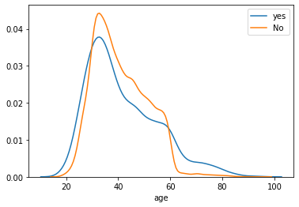

```
Dist plot of  balance
```

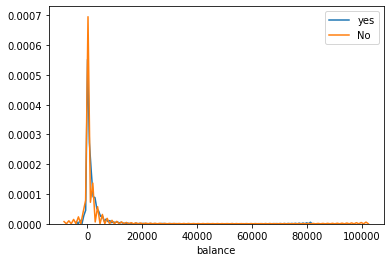

```
Dist plot of  day
```

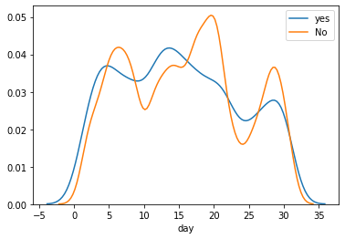

```
Dist plot of  duration
```

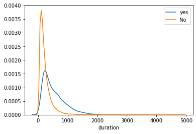

```
Dist plot of  campaign
```

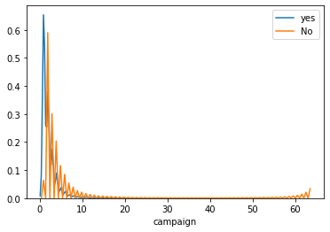

```
Dist plot of  pdays
```

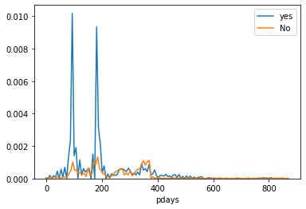

```
Dist plot of  previous
```

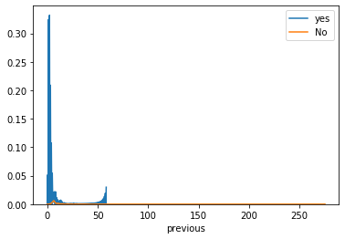

```
Dist plot of  education_primary
```

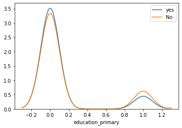

```
Dist plot of  education_secondary
```

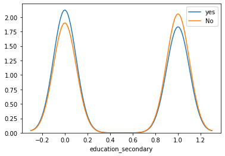

```
Dist plot of  education_tertiary
```

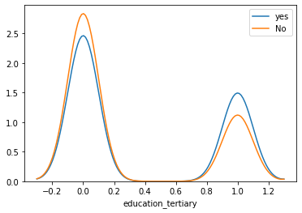

```
Dist plot of  education_unknown
```

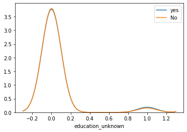

```
Dist plot of  month_apr
```

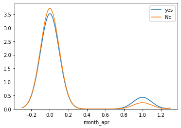

```
Dist plot of  month_aug
```

[39 more figures not shown]

```python
# Split the dataframe with Target = yes and Target = no
TargetYesDf = copyBankDf[copyBankDf['Target'] == 1]
TargetNoDf  = copyBankDf[copyBankDf['Target'] == 0]

# Get all predictor variables
colList = TargetYesDf.columns.tolist()
colList.remove('Target')

# Split the continous and categorical
ContList = colList[0:5]
catList  = colList[5:]

for col in ContList:
    sns.distplot(TargetYesDf[col], hist=False,label='yes')
    sns.distplot(TargetNoDf[col], hist=False,label='No')
    print("Dist plot of ",col)
    plot.legend()
    plot.show()

# Columns with categorical is shown in distplot with a bandwidth.Otherwise it throws error. Thatswhy
# categorical columns are splitted
for col in catList:
    sns.distplot(TargetYesDf[col], hist=False,label='yes',kde_kws={'bw':0.1})
    sns.distplot(TargetNoDf[col], hist=False,label='No',kde_kws={'bw':0.1})
    print("Dist plot of ",col)
    plot.legend()
    plot.show()
```

# Split the data into test and train

```python
# Split the predictor and target variables
X = copyBankDf.drop(['Target'],axis =1)
colNames = X.columns

# Target var
Y = copyBankDf['Target']
```

```python
# Make sure the data types of the predictor variables are not categorical
X.dtypes
```

```
age                    int64
balance                int64
day                    int64
duration               int64
campaign               int64
pdays                  int64
previous               int64
education_primary      uint8
education_secondary    uint8
education_tertiary     uint8
education_unknown      uint8
month_apr              uint8
month_aug              uint8
month_dec              uint8
month_feb              uint8
month_jan              uint8
month_jul              uint8
month_jun              uint8
month_mar              uint8
month_may              uint8
month_nov              uint8
month_oct              uint8
month_sep              uint8
job_admin.             uint8
job_blue-collar        uint8
job_entrepreneur       uint8
job_housemaid          uint8
job_management         uint8
job_retired            uint8
job_self-employed      uint8
job_services           uint8
job_student            uint8
job_technician         uint8
job_unemployed         uint8
job_unknown            uint8
default_no             uint8
default_yes            uint8
loan_no                uint8
loan_yes               uint8
housing_no             uint8
housing_yes            uint8
marital_divorced       uint8
marital_married        uint8
marital_single         uint8
contact_cellular       uint8
contact_telephone      uint8
contact_unknown        uint8
poutcome_failure       uint8
poutcome_other         uint8
poutcome_success       uint8
poutcome_unknown       uint8
dtype: object
```

```python
# Split the data in ratio of 70:30
from sklearn.model_selection import train_test_split
X_train, X_test, Y_train, Y_test = train_test_split(X, Y, test_size =0.3, random_state = 5)
X_train.head()
```

|  | age | balance | day | duration | campaign | pdays | previous | education_primary | education_secondary | education_tertiary | ... | marital_divorced | marital_married | marital_single | contact_cellular | contact_telephone | contact_unknown | poutcome_failure | poutcome_other | poutcome_success | poutcome_unknown |
| --- | --- | --- | --- | --- | --- | --- | --- | --- | --- | --- | --- | --- | --- | --- | --- | --- | --- | --- | --- | --- | --- |
| 42867 | 53 | 6571 | 3 | 208 | 1 | -1 | 0 | 0 | 0 | 1 | ... | 0 | 1 | 0 | 1 | 0 | 0 | 0 | 0 | 0 | 1 |
| 27173 | 50 | 231 | 21 | 397 | 2 | -1 | 0 | 0 | 1 | 0 | ... | 0 | 1 | 0 | 1 | 0 | 0 | 0 | 0 | 0 | 1 |
| 8875 | 39 | 518 | 4 | 608 | 2 | -1 | 0 | 0 | 1 | 0 | ... | 0 | 1 | 0 | 0 | 0 | 1 | 0 | 0 | 0 | 1 |
| 18330 | 42 | 634 | 31 | 451 | 2 | -1 | 0 | 0 | 0 | 1 | ... | 0 | 0 | 1 | 1 | 0 | 0 | 0 | 0 | 0 | 1 |
| 8306 | 58 | 1604 | 2 | 358 | 3 | -1 | 0 | 0 | 1 | 0 | ... | 0 | 1 | 0 | 0 | 0 | 1 | 0 | 0 | 0 | 1 |

5 rows × 51 columns

```python
#--------------------------------------------------------------
# Tried scaling the data as well but didnt see much improvement
#--------------------------------------------------------------

# from sklearn.preprocessing import StandardScaler
# sc=StandardScaler()
# sc.fit_transform(X_train)
# X_train = sc.fit_transform(X_train)
# X_test = sc.transform(X_test)
```

```python
# Data frame to hold the metrics of the various models
metricDf = pd.DataFrame()
```

# Deliverable - 3

## Logistic Regression Model

```python
from sklearn.linear_model import LogisticRegression as LogReg
logModel = LogReg( solver='liblinear')

# fit the model
logModel.fit(X_train,Y_train)

# get the coefficient of variables and print
coeff = pd.DataFrame(logModel.coef_)
print(coeff)

# get the model and score and print it
score = logModel.score(X_test,Y_test)
print("-------------------------------------------------")
print("Logistic regression score on test data = ", score)
print("-------------------------------------------------")
```

```
        0         1        2         3         4         5         6   \
0 -0.00236  0.000012  0.00622  0.004094 -0.081979  0.000208  0.006359

         7         8         9   ...        41        42       43        44  \
0 -0.397552 -0.230322 -0.053212  ... -0.130042 -0.417991 -0.15396  0.310722

        45        46        47        48        49        50
0  0.22208 -1.234795 -0.757994 -0.600192  1.487146 -0.830952

[1 rows x 51 columns]
-------------------------------------------------
Logistic regression score on test data =  0.9029784724270127
-------------------------------------------------
```

```python
# Function to get the scores given observed data, predicated data. Called by multiple models
from sklearn.metrics import confusion_matrix, recall_score, precision_score, f1_score, roc_auc_score,accuracy_score

def ModelMetrics(model,trainScore, testScore, observed, predicted, df):

    # Print the various score
    print("-------------------------------------------")
    print("Scores of model: ",model)
    print("-------------------------------------------")
    print("Train data Score =", trainScore)
    print("Test  data Score =", testScore)

    rcScore  = recall_score(observed, predicted)
    prScore  = precision_score(observed, predicted)
    rocScore = roc_auc_score(observed, predicted)
    acc      = accuracy_score(observed, predicted)
    f1Score  = f1_score(observed, predicted)

    print("Recall Score     =", rcScore)
    print("Precision Score  =", prScore)
    print("AUC Score        =", rocScore)
    print("Accuracy Score   =", acc)
    print("F1 Score         =", f1Score)

    df = df.append({'Model':model,
                       'Train Score':trainScore,
                       'Test Score': testScore,
                       'Recall':rcScore,
                       'Precision':prScore,
                       'Roc Score':rocScore,
                       'accuracy': acc,
                       'f1 score': f1Score},ignore_index=True)

    # Draw the confusion matrix
    confMat = confusion_matrix(observed,predicted)
    sns.heatmap(confMat, annot=True,  fmt='.2f', xticklabels = [0,1] , yticklabels = [0,1] )
    plot.ylabel('Observed')
    plot.xlabel('Predicted')
    plot.show()

    return df
```

```python
y_predict = logModel.predict(X_test)
```

```python
# Score of the decision tree
trainScore = logModel.score(X_train,Y_train)
testScore  = logModel.score(X_test,Y_test)
```

```
-------------------------------------------
Scores of model:  Logistic Regression
-------------------------------------------
Train data Score = 0.9001485132871995
Test  data Score = 0.9029784724270127
Recall Score     = 0.3458411507191995
Precision Score  = 0.6719319562575942
AUC Score        = 0.661637666876524
Accuracy Score   = 0.9029784724270127
F1 Score         = 0.45664739884393063
```

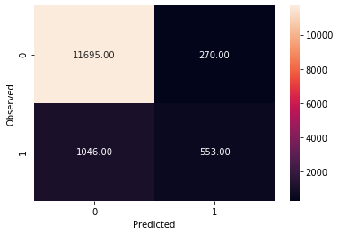

```python
# Get the various metrics of the model
metricDf = ModelMetrics("Logistic Regression",trainScore,testScore, Y_test,y_predict,metricDf)
```

## Decision Tree

```python
from sklearn.tree import DecisionTreeClassifier
dt=DecisionTreeClassifier(criterion='gini',random_state=1)
dt.fit(X_train,Y_train)
pred_dt=dt.predict(X_test)
```

```python
# Score of the decision tree
trainScore = dt.score(X_train,Y_train)
testScore  = dt.score(X_test,Y_test)
```

```python
# Confusion matrix
confusion_matrix(Y_test,pred_dt)
```

```
array([[11110,   855],
       [  818,   781]], dtype=int64)
```

```
-------------------------------------------
Scores of model:  Decision Tree
-------------------------------------------
Train data Score = 1.0
Test  data Score = 0.876658802713064
Recall Score     = 0.4884302689180738
Precision Score  = 0.4773838630806846
AUC Score        = 0.7084859242626307
Accuracy Score   = 0.876658802713064
F1 Score         = 0.48284389489953633
```

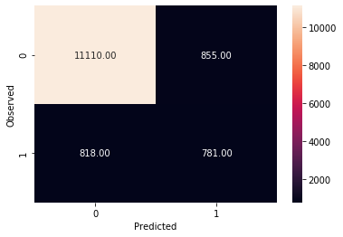

```python
# Draw the confusion matrix
metricDf = ModelMetrics("Decision Tree",trainScore,testScore, Y_test,pred_dt,metricDf)
```

```python
featDf = pd.DataFrame(dt.feature_importances_,index=X_train.columns,columns=["Importance"])
featDf
```

|  | Importance |
| --- | --- |
| age | 0.085982 |
| balance | 0.104952 |
| day | 0.082637 |
| duration | 0.281155 |
| campaign | 0.026692 |
| pdays | 0.038005 |
| previous | 0.015343 |
| education_primary | 0.004268 |
| education_secondary | 0.007681 |
| education_tertiary | 0.005808 |
| education_unknown | 0.006072 |
| month_apr | 0.015111 |
| month_aug | 0.008041 |
| month_dec | 0.004391 |
| month_feb | 0.008493 |
| month_jan | 0.004716 |
| month_jul | 0.006593 |
| month_jun | 0.014789 |
| month_mar | 0.013231 |
| month_may | 0.006857 |
| month_nov | 0.005763 |
| month_oct | 0.010494 |
| month_sep | 0.008200 |
| job_admin. | 0.009646 |
| job_blue-collar | 0.005646 |
| job_entrepreneur | 0.003826 |
| job_housemaid | 0.001954 |
| job_management | 0.011345 |
| job_retired | 0.001791 |
| job_self-employed | 0.004663 |
| job_services | 0.004120 |
| job_student | 0.006422 |
| job_technician | 0.009731 |
| job_unemployed | 0.003529 |
| job_unknown | 0.001534 |
| default_no | 0.001391 |
| default_yes | 0.000703 |
| loan_no | 0.004634 |
| loan_yes | 0.004960 |
| housing_no | 0.013972 |
| housing_yes | 0.004321 |
| marital_divorced | 0.008521 |
| marital_married | 0.009398 |
| marital_single | 0.006103 |
| contact_cellular | 0.004895 |
| contact_telephone | 0.001812 |
| contact_unknown | 0.012115 |
| poutcome_failure | 0.002173 |
| poutcome_other | 0.004026 |
| poutcome_success | 0.090367 |
| poutcome_unknown | 0.001131 |

## Result

### 1. Performing well on the train data but not on test data. Overfitting on training data. Setting a threshold on the max depth may lead to good performance

### 2. As per our hypothesis based on the bivariate analysis, the feature importance shows that duration, balance are important than others.

## Regulated Decision Tree

```python
dtReg=DecisionTreeClassifier(criterion='gini',random_state=1,max_depth=6)
dtReg.fit(X_train,Y_train)
pred_dtR=dtReg.predict(X_test)
```

```python
# Score of the regulated decision tree
trainScore = dtReg.score(X_train,Y_train)
testScore  = dtReg.score(X_test,Y_test)
```

```
-------------------------------------------
Scores of model:  Regulated Decision Tree
-------------------------------------------
Train data Score = 0.9083325433690397
Test  data Score = 0.903347095252138
Recall Score     = 0.3827392120075047
Precision Score  = 0.6538461538461539
AUC Score        = 0.6778301158240617
Accuracy Score   = 0.903347095252138
F1 Score         = 0.48284023668639053
```

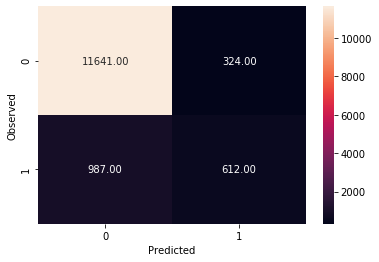

```python
#Draw the confusion matrix
metricDf = ModelMetrics("Regulated Decision Tree",trainScore,testScore,Y_test,pred_dtR,metricDf )
```

## Visualizing the decision tree

```python
from sklearn import tree
dtGraphFile = open("dt_graph","w")
graphData = tree.export_graphviz(dtReg,out_file=dtGraphFile,feature_names=colNames)
dtGraphFile.close()
```

```python
pip install graphviz
```

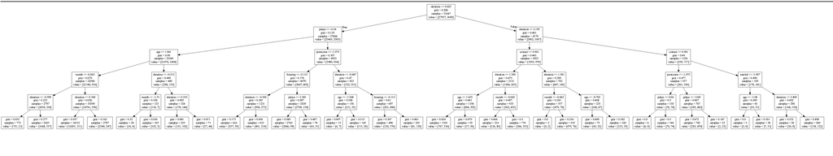

## Bagging

```
-------------------------------------------
Scores of model:  Bagging Classifier
-------------------------------------------
Train data Score = 0.9998420071412772
Test  data Score = 0.9073282217634916
Recall Score     = 0.47529706066291433
Precision Score  = 0.6451612903225806
AUC Score        = 0.7201809164576586
Accuracy Score   = 0.9073282217634916
F1 Score         = 0.5473532589124954
```

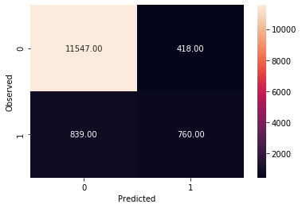

```python
from sklearn.ensemble import BaggingClassifier
bagClas = BaggingClassifier(n_estimators=40, random_state=1)
bagClas.fit(X_train,Y_train)

trainScore = bagClas.score(X_train,Y_train)
testScore  = bagClas.score(X_test,Y_test)

y_predict_bagCl = bagClas.predict(X_test)
metricDf = ModelMetrics("Bagging Classifier",trainScore,testScore,Y_test,y_predict_bagCl,metricDf)
```

## Bagging uses complex model. And the accuracy is improved little bit than the decision tree but almost as same as the regularized decision tree.

## Ada Boosting: To be started with a simple model

```
-------------------------------------------
Scores of model:  Ada Boosting Classifier
-------------------------------------------
Train data Score = 0.8995481404240528
Test  data Score = 0.8991447950457092
Recall Score     = 0.38461538461538464
Precision Score  = 0.6156156156156156
AUC Score        = 0.6762608891317625
Accuracy Score   = 0.8991447950457092
F1 Score         = 0.4734411085450347
```

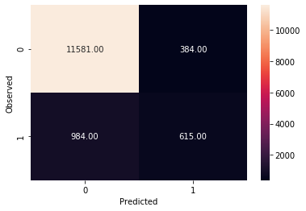

```python
from sklearn.ensemble import AdaBoostClassifier
adaBoostCl = AdaBoostClassifier(n_estimators=30, random_state=1)
adaBoostCl.fit(X_train,Y_train)

trainScore = adaBoostCl.score(X_train,Y_train)
testScore  = adaBoostCl.score(X_test,Y_test)

y_predict_adaCl = adaBoostCl.predict(X_test)
metricDf = ModelMetrics("Ada Boosting Classifier",trainScore,testScore,Y_test,y_predict_adaCl,metricDf)
```

## Gradient Boosting

```
-------------------------------------------
Scores of model:  Gradient Boosting Classifier
-------------------------------------------
Train data Score = 0.9023288147375739
Test  data Score = 0.9018726039516367
Recall Score     = 0.2858036272670419
Precision Score  = 0.7074303405572755
AUC Score        = 0.635003777695368
Accuracy Score   = 0.9018726039516367
F1 Score         = 0.4071269487750557
```

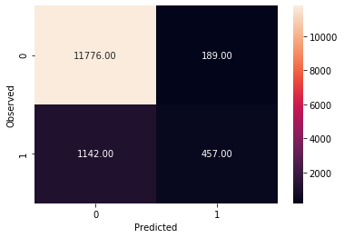

```python
from sklearn.ensemble import GradientBoostingClassifier
gradBoostCl = GradientBoostingClassifier(n_estimators=30, random_state=1)
gradBoostCl.fit(X_train,Y_train)

trainScore = gradBoostCl.score(X_train,Y_train)
testScore  = gradBoostCl.score(X_test,Y_test)

y_predict_gradCl = gradBoostCl.predict(X_test)
metricDf = ModelMetrics("Gradient Boosting Classifier",trainScore,testScore,Y_test,y_predict_gradCl,metricDf)
```

## Random Forest Classifier

```
-------------------------------------------
Scores of model:  Random Forest Classifier
-------------------------------------------
Train data Score = 0.999146838562897
Test  data Score = 0.9060749041580655
Recall Score     = 0.44090056285178236
Precision Score  = 0.6497695852534562
AUC Score        = 0.7045706324497106
Accuracy Score   = 0.9060749041580655
F1 Score         = 0.5253353204172876
```

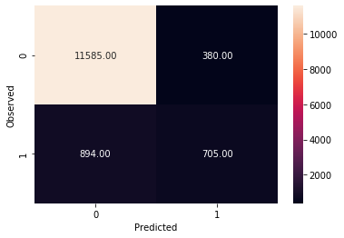

```python
from sklearn.ensemble import RandomForestClassifier
randForestCl = RandomForestClassifier(n_estimators=30, random_state=1, max_features=25)
randForestCl.fit(X_train,Y_train)

trainScore = randForestCl.score(X_train,Y_train)
testScore  = randForestCl.score(X_test,Y_test)

y_predict_randForest = randForestCl.predict(X_test)
metricDf = ModelMetrics("Random Forest Classifier",trainScore,testScore,Y_test,y_predict_randForest, metricDf)
```

```python
metricDf
```

|  | Model | Precision | Recall | Roc Score | Test Score | Train Score | accuracy | f1 score |
| --- | --- | --- | --- | --- | --- | --- | --- | --- |
| 0 | Logistic Regression | 0.671932 | 0.345841 | 0.661638 | 0.902978 | 0.900149 | 0.902978 | 0.456647 |
| 1 | Decision Tree | 0.477384 | 0.488430 | 0.708486 | 0.876659 | 1.000000 | 0.876659 | 0.482844 |
| 2 | Regulated Decision Tree | 0.653846 | 0.382739 | 0.677830 | 0.903347 | 0.908333 | 0.903347 | 0.482840 |
| 3 | Bagging Classifier | 0.645161 | 0.475297 | 0.720181 | 0.907328 | 0.999842 | 0.907328 | 0.547353 |
| 4 | Ada Boosting Classifier | 0.615616 | 0.384615 | 0.676261 | 0.899145 | 0.899548 | 0.899145 | 0.473441 |
| 5 | Gradient Boosting Classifier | 0.707430 | 0.285804 | 0.635004 | 0.901873 | 0.902329 | 0.901873 | 0.407127 |
| 6 | Random Forest Classifier | 0.649770 | 0.440901 | 0.704571 | 0.906075 | 0.999147 | 0.906075 | 0.525335 |

# Based on the scores, I prefer Bagging classifer as the precision, recall and test score is high.

# Some of the other model have little bit better recall value than bagging (for example gradient boosting has a precision of 0.7 but recall is less), but bagging has good precison and recall .

# Other methods tried to improve the performance:

## 1. Tried scaling the training and testing data with StandardScaler. But did not see much improvement. There are huge number of outliers and scaling them does not make sense.

## 2. Instead of replacing with dummies, I tried to replace the categorical values with integers (like shown below). But recall score goes very low.

```python
# Replace categorical values with integers
"""
copyBankDf['education'].replace(['unknown','primary','secondary','tertiary'],[-1,1,2,3],inplace=True

copyBankDf['month'].replace(['jan','feb','mar','apr','may','jun','jul','aug','sep','oct','nov','dec'],
                            [1,2,3,4,5,6,7,8,9,10,11,12],inplace=True)

copyBankDf['default'].replace(['no','yes'],[0,1],inplace=True)

copyBankDf['loan'].replace(['no','yes'],[0,1],inplace=True)

copyBankDf['housing'].replace(['no','yes'],[0,1],inplace=True)

"""
```

```
" \ncopyBankDf['education'].replace(['unknown','primary','secondary','tertiary'],[-1,1,2,3],inplace=True\n\ncopyBankDf['month'].replace(['jan','feb','mar','apr','may','jun','jul','aug','sep','oct','nov','dec'],\n                            [1,2,3,4,5,6,7,8,9,10,11,12],inplace=True)\n                …
```

## 3. Tried converting the categorical values with encoders

```python
"""
from sklearn.preprocessing import LabelEncoder
lblEncoder = LabelEncoder()
copyBankDf['job']      = lblEncoder.fit_transform(copyBankDf['job'])
copyBankDf['marital']  = lblEncoder.fit_transform(copyBankDf['marital'])
copyBankDf['contact']  = lblEncoder.fit_transform(copyBankDf['contact'])
copyBankDf['poutcome'] = lblEncoder.fit_transform(copyBankDf['poutcome'])
"""
```

```
"\nfrom sklearn.preprocessing import LabelEncoder\nlblEncoder = LabelEncoder()\ncopyBankDf['job']      = lblEncoder.fit_transform(copyBankDf['job'])\ncopyBankDf['marital']  = lblEncoder.fit_transform(copyBankDf['marital'])\ncopyBankDf['contact']  = lblEncoder.fit_transform(copyBankDf['contact'])\nco…
```

## 4. Binning the contionus variables also does not help (shown below).

```python
"""
# Bin the age
copyBankDf.loc[copyBankDf['age'] < 25, 'age']   = 1
copyBankDf.loc[(copyBankDf['age'] > 25) & (copyBankDf['age'] <= 40), 'age'] = 2
copyBankDf.loc[(copyBankDf['age'] > 40) & (copyBankDf['age'] <= 60), 'age'] = 3
copyBankDf.loc[(copyBankDf['age'] > 60), 'age'] = 4

# Bin the duration
copyBankDf.loc[copyBankDf['duration']  < 30, 'duration']   = 1
copyBankDf.loc[(copyBankDf['duration'] > 30)  & (copyBankDf['duration'] <= 180), 'duration'] = 2
copyBankDf.loc[(copyBankDf['duration'] > 180) & (copyBankDf['duration'] <= 365), 'duration'] = 3
copyBankDf.loc[(copyBankDf['duration'] > 365) & (copyBankDf['duration'] <= 730), 'duration'] = 4
copyBankDf.loc[(copyBankDf['duration'] > 730), 'duration'] = 5


# Bin the pdays as well ( not contacted or contacted more than 900 means -1)
copyBankDf.loc[copyBankDf['pdays']     < 90, 'pdays']   = 1
copyBankDf.loc[(copyBankDf['pdays'] > 90)  & (copyBankDf['pdays'] <= 365), 'pdays'] = 2
copyBankDf.loc[(copyBankDf['pdays'] > 365) & (copyBankDf['pdays'] <= 730), 'pdays'] = 3
copyBankDf.loc[(copyBankDf['pdays'] > 730), 'pdays'] = 4

"""
```

```
"\n# Bin the age\ncopyBankDf.loc[copyBankDf['age'] < 25, 'age']   = 1\ncopyBankDf.loc[(copyBankDf['age'] > 25) & (copyBankDf['age'] <= 40), 'age'] = 2\ncopyBankDf.loc[(copyBankDf['age'] > 40) & (copyBankDf['age'] <= 60), 'age'] = 3\ncopyBankDf.loc[(copyBankDf['age'] > 60), 'age'] = 4\n\n# Bin the du…
```

## All of the above method does not improve the score rather in some cases it reduced the score.